# EkonometriaProj

#### 5.3. Test Breuscha-Pagana (heteroskedastyczność)

```r
bptest(model_final)
```

```
##
##  studentized Breusch-Pagan test
##
## data:  model_final
## BP = 526.94, df = 23, p-value < 2.2e-16
```

```r
bptest(model_gam)
```

```
##
##  studentized Breusch-Pagan test
##
## data:  model_gam
## BP = 478.62, df = 23, p-value < 2.2e-16
```

```r
coeftest(model_final, vcov = vcovHC(model_gam, type = "HC1"))
```

```
##
## t test of coefficients:
##
##                                   Estimate Std. Error t value  Pr(>|t|)
## (Intercept)                       9.918026   0.107490 92.2692 < 2.2e-16 ***
## airlineAirAsia                   -0.547587   0.150569 -3.6368 0.0002769 ***
## airlineGO_FIRST                  -0.059836   0.116942 -0.5117 0.6088843
## airlineIndigo                    -0.214495   0.117035 -1.8327 0.0668596 .
## airlineSpiceJet                  -0.061048   0.193580 -0.3154 0.7524910
## airlineVistara                    0.092907   0.068985  1.3468 0.1780751
## stopstwo_or_more                  0.261638   0.151659  1.7252 0.0845151 .
## stopszero                        -0.453183   0.362361 -1.2506 0.2110843
## arrival_timeEarly_Morning        -0.131033   0.131258 -0.9983 0.3181537
## arrival_timeEvening               0.038102   0.101942  0.3738 0.7085858
## arrival_timeLate_Night            0.010581   0.139986  0.0756 0.9397490
## arrival_timeMorning              -0.062698   0.099801 -0.6282 0.5298634
## arrival_timeNight                -0.012106   0.097425 -0.1243 0.9011101
## airlineAirAsia:stopstwo_or_more  -0.140520   0.358297 -0.3922 0.6949246
## airlineGO_FIRST:stopstwo_or_more -0.318777   0.792578 -0.4022 0.6875396
## airlineIndigo:stopstwo_or_more   -0.020352   0.617139 -0.0330 0.9736926
## airlineSpiceJet:stopstwo_or_more        NA   0.000000      NA        NA
## airlineVistara:stopstwo_or_more   0.040941   0.216264  0.1893 0.8498526
## airlineAirAsia:stopszero          0.544272   0.303106  1.7956 0.0725688 .
## airlineGO_FIRST:stopszero         0.043031   0.275349  0.1563 0.8758166
## airlineIndigo:stopszero           0.216787   0.237693  0.9120 0.3617561
## airlineSpiceJet:stopszero         0.138134   0.314164  0.4397 0.6601685
## airlineVistara:stopszero         -0.049908   0.240785 -0.2073 0.8357986
## ---
## Signif. codes:  0 '***' 0.001 '**' 0.01 '*' 0.05 '.' 0.1 ' ' 1
```

```r
coeftest(model_gam, vcov = vcovHC(model_gam, type = "HC1"))
```

```
##
## z test of coefficients:
##
##                                    Estimate Std. Error z value  Pr(>|z|)
## (Intercept)                       8.6929043  0.1074901 80.8716 < 2.2e-16 ***
## airlineAirAsia                   -0.5838250  0.1505687 -3.8775 0.0001056 ***
## airlineGO_FIRST                  -0.0968943  0.1169417 -0.8286 0.4073482
## airlineIndigo                    -0.2675998  0.1170351 -2.2865 0.0222254 *
## airlineSpiceJet                  -0.0484497  0.1935800 -0.2503 0.8023687
## airlineVistara                    0.0743739  0.0689851  1.0781 0.2809824
## stopstwo_or_more                  0.2229120  0.1516593  1.4698 0.1416102
## stopszero                         0.1330117  0.3623613  0.3671 0.7135674
## arrival_timeEarly_Morning        -0.1047529  0.1312578 -0.7981 0.4248296
## arrival_timeEvening               0.0386833  0.1019422  0.3795 0.7043443
## arrival_timeLate_Night           -0.0010126  0.1399861 -0.0072 0.9942284
## arrival_timeMorning              -0.0360028  0.0998010 -0.3607 0.7182893
## arrival_timeNight                -0.0126848  0.0974246 -0.1302 0.8964070
## airlineAirAsia:stopstwo_or_more  -0.1070402  0.3582971 -0.2987 0.7651330
## airlineGO_FIRST:stopstwo_or_more -0.2742159  0.7925780 -0.3460 0.7293580
## airlineIndigo:stopstwo_or_more    0.0022220  0.6171389  0.0036 0.9971273
## airlineSpiceJet:stopstwo_or_more  0.0000000  0.0000000     NaN       NaN
## airlineVistara:stopstwo_or_more   0.0830042  0.2162640  0.3838 0.7011197
## airlineAirAsia:stopszero          0.6340173  0.3031062  2.0917 0.0364624 *
## airlineGO_FIRST:stopszero         0.1121323  0.2753494  0.4072 0.6838344
## airlineIndigo:stopszero           0.3464506  0.2376926  1.4576 0.1449626
## airlineSpiceJet:stopszero         0.1202095  0.3141638  0.3826 0.7019917
## airlineVistara:stopszero         -0.0114792  0.2407849 -0.0477 0.9619759
## s(duration).1                     0.9669151  0.6195813  1.5606 0.1186195
## s(duration).2                    -1.3729973  3.2790849 -0.4187 0.6754255
## s(duration).3                    -0.3841996  0.6687484 -0.5745 0.5656258
## s(duration).4                    -0.6768802  2.1139176 -0.3202 0.7488154
## s(duration).5                    -0.4169079  0.5955256 -0.7001 0.4838854
## s(duration).6                    -0.3812233  1.8854279 -0.2022 0.8397646
## s(duration).7                     0.4912682  0.9923524  0.4951 0.6205618
## s(duration).8                     0.3786818  7.4032706  0.0512 0.9592055
## s(duration).9                     1.5865291  1.4154974  1.1208 0.2623611
## s(days_left).1                    0.0845233  0.2976311  0.2840 0.7764205
## s(days_left).2                   -0.4949825  0.8173468 -0.6056 0.5447827
## s(days_left).3                    0.2989628  0.2220986  1.3461 0.1782763
## s(days_left).4                    0.5579147  0.5896534  0.9462 0.3440598
## s(days_left).5                    0.0580248  0.2526973  0.2296 0.8183858
## s(days_left).6                    0.8577642  0.5967668  1.4374 0.1506179
## s(days_left).7                   -0.0143316  0.3001189 -0.0478 0.9619132
## s(days_left).8                   -1.6420262  1.3673116 -1.2009 0.2297838
## s(days_left).9                   -0.7768953  0.6187612 -1.2556 0.2092735
## ---
## Signif. codes:  0 '***' 0.001 '**' 0.01 '*' 0.05 '.' 0.1 ' ' 1
```

W celu zbadania poprawności założeń modelu, przeprowadzono test Breuscha–Pagana dla klasycznego modelu liniowego (`model_final`) oraz modelu uogólnionego addytywnego (`model_gam`). W obu przypadkach otrzymano bardzo niskie wartości p-value (< 2.2e-16), co wskazuje na istotną statystycznie heteroskedastyczność reszt. Oznacza to, że wariancja składnika losowego nie jest stała, co może prowadzić do błędnych wniosków przy standardowej estymacji. W związku z tym zastosowano estymację odporną na heteroskedastyczność za pomocą korekty White’a (przez `vcovHC`).

#### 5.4. Sprawdzanie normalności reszt i test Jarque Bera

```r
residuals_gam <- residuals(model_gam)
jarque.bera.test(residuals_gam)
```

```
##
##  Jarque Bera Test
##
## data:  residuals_gam
## X-squared = 2211.1, df = 2, p-value < 2.2e-16
```

W celu oceny zgodności rozkładu reszt z rozkładem normalnym przeprowadzono test Jarque-Bera. Uzyskano wartość statystyki testowej X² = 2211.1, przy liczbie stopni swobody równej 2 oraz bardzo niskim poziomie istotności p < 2.2e-16. Taki wynik jednoznacznie wskazuje na odrzucenie hipotezy zerowej o normalności rozkładu reszt.

Tego rodzaju wynik nie jest zaskakujący przy dużych próbach, ponieważ testy normalności są bardzo czułe na nawet niewielkie odchylenia. Niemniej jednak, niezgodność z normalnością może wpływać na poprawność klasycznych testów istotności (opartych na założeniu o normalnych resztach), dlatego w analizie zastosowano korektę wariancji odporną na heteroskedastyczność i brak normalności (vcovHC).

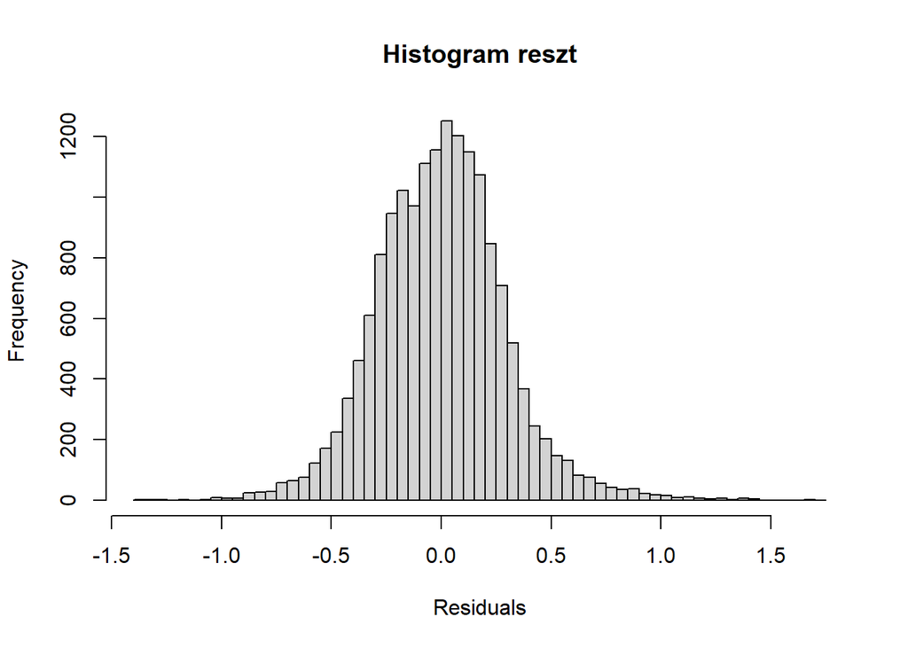

```r
hist(residuals(model_gam), breaks = 50, main = "Histogram reszt", xlab = "Residuals")
```

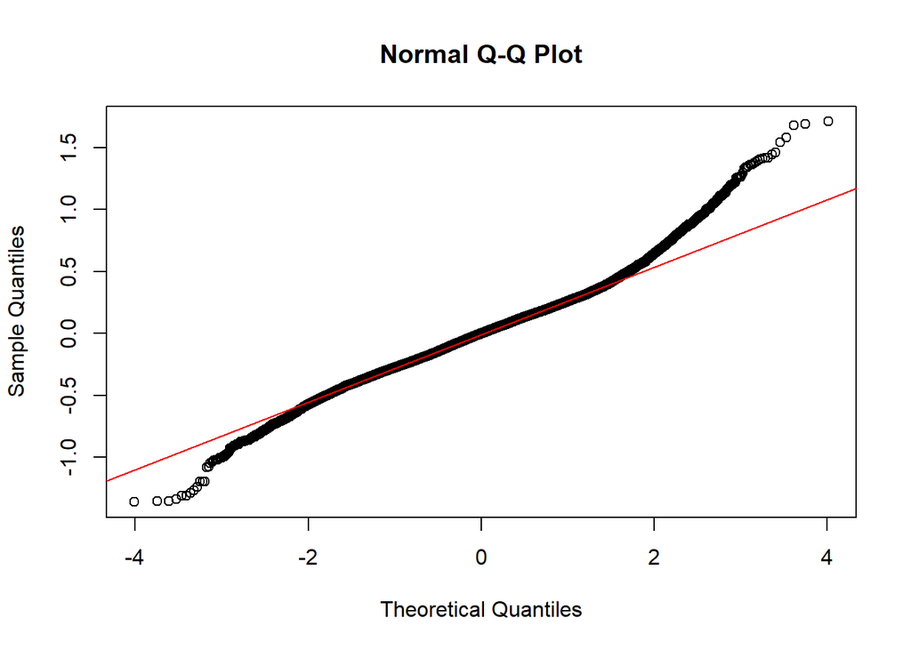

```r
qqnorm(residuals(model_gam))
qqline(residuals(model_gam), col = "red")
```

Reszty są wyraźnie dzwonowate (histogram), ale QQ-plot pokazuje lekkie odstępstwa w skrajnych ogonach: obserwacje ekstremalne leżą powyżej linii odniesienia po prawej i poniżej po lewej, co wskazuje na niewielką leptokurtozę. W efekcie test Jarque-Bera przy tak dużej próbie odrzuca normalność (p < 2·10⁻¹⁶), choć wizualnie większość masy reszt mieści się blisko rozkładu normalnego. W praktyce oznacza to, że centralna część rozkładu jest dobrze odwzorowana.

#### 5.5 Współliniowość

```r
model_simple <- lm(log_price ~ airline + stops + log(duration) + log(days_left + 1) + arrival_time, data = train_economy)
vif(model_simple)
```

```
##                        GVIF Df GVIF^(1/(2*Df))
## airline            1.642397  5        1.050867
## stops              2.987578  2        1.314709
## log(duration)      3.610713  1        1.900188
## log(days_left + 1) 1.009697  1        1.004837
## arrival_time       1.154125  5        1.014437
```

Przeprowadzając analizę współliniowości na modelu uproszczonym o interakcję dochodzimy do wniosków: W modelu nie występuje istotna współliniowość między zmiennymi objaśniającymi. Wszystkie wartości VIF^(1/(2*Df)) są znacznie poniżej powszechnie przyjmowanej granicy 5, a nawet 2. Szczególną uwagę można zwrócić jedynie na zmienną `log(duration)`, która osiąga wartość 1.90 – wskazuje to na umiarkowaną korelację z innymi zmiennymi, ale nie na poziomie wymagającym interwencji.

Model pod względem współliniowości jest stabilny i dobrze uwarunkowany, co oznacza, że oszacowania parametrów są wiarygodne, a ryzyko niestabilności estymacji – niskie.

### 6. Predykcja

```r
test_economy <- test_economy %>%
  mutate(
    pred_log_price = predict(model_final, newdata = test_economy),  # predykcja na skali log_price
    pred_price = exp(pred_log_price),                              # przeskalowanie do oryginalnej skali price
    error = pred_price - price,                                    # błąd bezwzględny
    abs_error = abs(error),
    rel_error = error / price                                      # względny błąd (procentowy)
  )
```